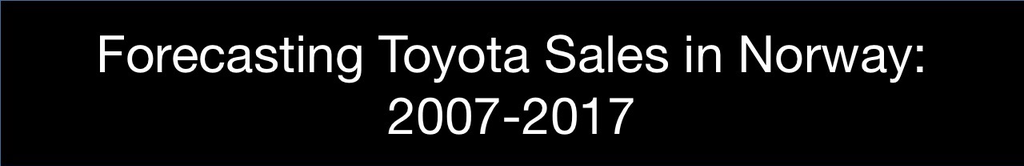

### Linear Regression

The goal of linear regression is to fit a straight line to scattered data points, and to do so in a way that minimizes the sum distance (sum of squares) between the regression line and the data points. However, linear regression rests on certain assumptions, one of which is uncorrelated residuals (autocorrelation), which is often violated by time series data, and can inflate the confidence interval of the estimate.

Before moving on to the analysis, keep in mind that finding the best model given the characteristics of your data is the ultimate goal of any forecasting analysis. Here I simply show how to conduct linear regression with time series, but it is just the beginning of an analysis, as different types of models must be tested. What’s important is that you know how to compare the performance different models, which is included in the analysis.

### The Scenario

We have 10 years’ worth of monthly sales data for all Toyota automobiles sold in Norway. The goal is to estimate demand for Toyota automobiles in Norway for the next 3 months. A regression model will be used to conduct this analysis, modeling trend and seasonality components as predictors. To start, a regression model is created using the majority of the data, which is then used to predict the excluded data. How well the model performs gives a sense how accurate the final regression model will perform with new data.

### The Dataset

The dataset being analyzed is Kaggle’s Norwegian Monthly Automobile Sales data, from January 2007 to January 2017. The first 118 months will be considered ‘training data’, and is used to create the regression model. The final 3 months will be ‘test data’ used to assess the model’s performance. How the model performs with the test data is indicative of how the final model will perform with future data.

### Import Data

The dataset consists of 3 files, but only the `norway_new_car_sales_by_make.csv` file is needed.

```r
by_make <- read.csv("NewCarSalesNorway/norway_new_car_sales_by_make.csv")
```

### Load Libraries

The ‘dplyr’ and ‘tidyr’ libraries are highly useful for data manipulation, and ‘ggplot2’ is used for visually appealing graphs.

```r
library(dplyr); library(tidyr); library(ggplot2)
```

### Glimpse

Here we see the initial values for each variable, the name and data type of each variable, as well as the total number of observations.

```r
glimpse(by_make)
```

```
## Observations: 4,377
## Variables: 5
## $ Year     <int> 2007, 2007, 2007, 2007, 2007, 2007, 2007, 2007, 2007,...
## $ Month    <int> 1, 1, 1, 1, 1, 1, 1, 1, 1, 1, 1, 1, 1, 1, 1, 1, 1, 1,...
## $ Make     <fctr> Toyota, Volkswagen, Peugeot, Ford, Volvo, Skoda, Ope...
## $ Quantity <int> 2884, 2521, 1029, 870, 693, 665, 622, 599, 423, 362, ...
## $ Pct      <dbl> 22.7, 19.9, 8.1, 6.9, 5.5, 5.2, 4.9, 4.7, 3.3, 2.9, 2...
```

### Separate Training and Test Data

Now we divide the training and test data by indexing rows. Upon running `View(by_make)` one can scroll down and identify the row number that separates the final 3 months from the rest of the data.

```r
train_data <- by_make[1:4273,]
test_data <- by_make[4274:4377,]
```

The data frame ‘train_toy’ is created to hold the training data, and a new variable ‘Date’ is created that combines ‘Year’ and ‘Month’.

```r
train_toy <- train_data %>%
  mutate(Date=as.Date(paste(Year, Month, "1", sep="-"))) %>%
  select(Date, Year, Month, Make, Quantity) %>%
  filter(Make=="Toyota")
```

## Line Graph

Below ‘Quantity’ is plotted across the entire time series for the training data. The first data point appears to be an outlier. There also appear to be strong seasonality effects evidenced by the sharp drop in demand at the end of each year (December). However, there is no obvious trend apart from a general decline in the first few years, which then levels off.

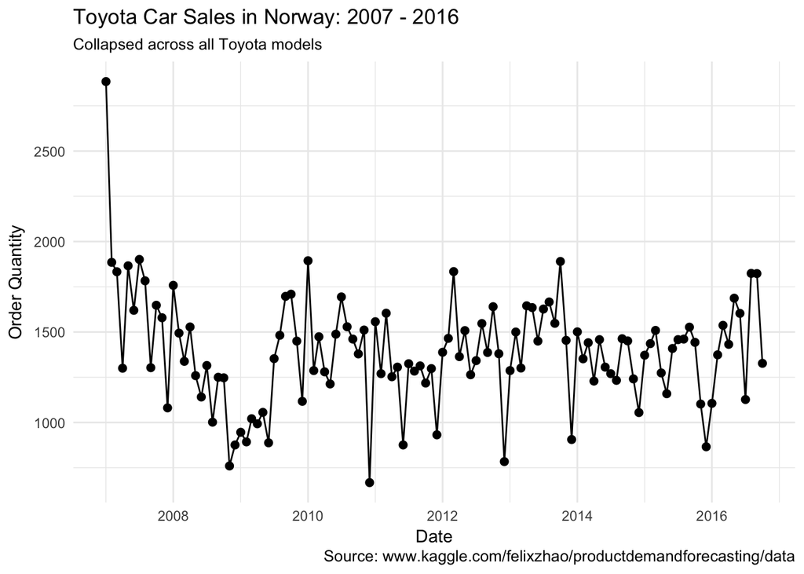

```r
 train_toy %>%
   ggplot(aes(x=Date, y=Quantity)) +
   geom_line() +
   geom_point(size=2) +
   theme_minimal() +
   scale_colour_brewer(palette = "Set1") +
   labs(y="Order Quantity",
        x="Date",
        color=NULL,
        title="Toyota Car Sales in Norway: 2007 - 2016",
        subtitle="Collapsed across all Toyota models",
        caption="Source: www.kaggle.com/felixzhao/productdemandforecasting/data")
```

The ‘Quantity’ column from ‘train_toy’ is converted into a time series object with `ts()`, which comes from the ‘forecast’ library. This time series object ‘y’ is needed for the time series linear regression, and will be used in the forecasting function.

The frequency input parameter indicates how often the data were measured per year, which in this case is monthly, so 12 is entered. With `tsclean()` the missing cases and outlier values are replaced with values derived from linear interpolation estimates that account for seasonality effects.

```r
library(forecast)

y <- train_toy$Quantity %>%
  ts(frequency=12) %>%
  tsclean()
```

### Time Series Components

Time series data consists of 4 components—trend, seasonality, cycle, and the remainder.

- **Trend**: general flucuations across wide ranges of the time series.
- **Seasonality**: flucuations around certain months within a year.
- **Cycle**: flucuations not fixed to a specific time period, spanning at least several years.
- **Remainder**: the remaining variance not exaplained by trend or seasonality.

The `stl()` function strips the trend, seasonal, and remainder components from the time series ‘y’, which is then plotted with `autoplot()`—a more visually appealing version of `plot()`.

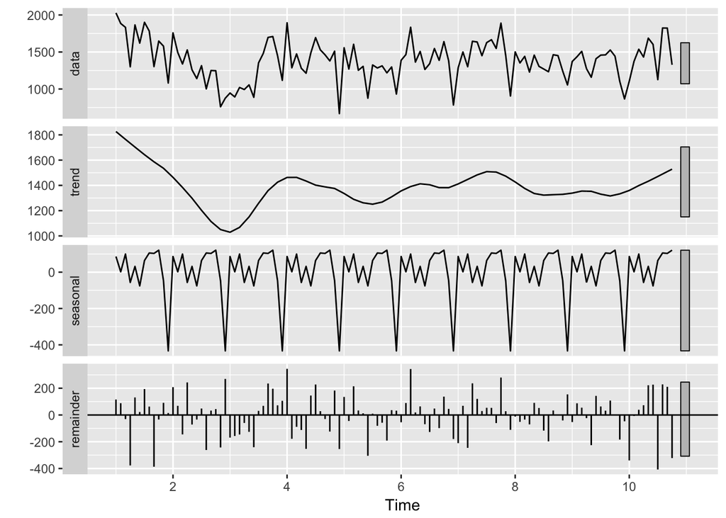

```r
autoplot(stl(y, s.window = "periodic"))
```

### Autocorrelation

Linear Regression rests on a number of assumptions, and violations of these assumptions appear as certain patterns within the data. The first pattern to look for is autocorrelation, where each data point is correlated with the data point that came before it (lag 1), or the point before that (lag 2), and so on.

Partial Autocorrelation Factor (PACF) is a measure of correlation between each data point, and all of the preceding (lag) data points. PACF values that cross the dotted blue threshold signify that the data points are correlated with values at that specific lag within the time series. With the exception of lag 1, any point crossing the threshold is evidence of autocorrelation, and here we spot 4 points crossing the threshold—two of them just barely.

The presence of autocorrelation does not mean that the regression estimate will be incorrect, but it will inflate the prediction intervals, making the estimate less precise.

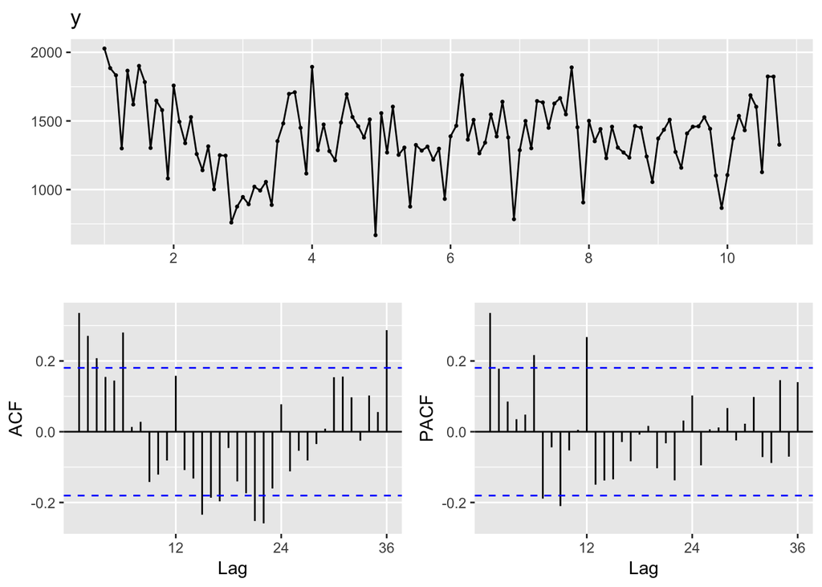

```r
ggtsdisplay(y, plot.type = "partial")
```

### Stationarity

Another key assumption for time series regression is stationarity, which refers to statistical properties like the mean and variance of a time series remaining stable over time. A popular method to test for stationarity is the Augmented Dickey-Fuller Test, which is run with `adf.test()` from the ‘tseries’ library.

As we can see below, the null hypothesis of non-stationarity is rejected, indicating that the time series is in fact stationary, despite the few autocorrelations previously observed.

```r
library(tseries)
adf.test(y, alternative = "stationary")
```

```
##
##  Augmented Dickey-Fuller Test
##
## data:  y
## Dickey-Fuller = -3.5848, Lag order = 4, p-value = 0.03766
## alternative hypothesis: stationary
```

Before moving on, the data frame ‘test_toy’ is created to hold the test data, and in terms of structure is identical to the ‘train_toy’ data frame.

```r
test_toy <- test_data %>%
  mutate(Date=as.Date(paste(Year, Month, "1", sep="-"))) %>%
  select(Date, Year, Month, Make, Quantity) %>%
  filter(Make=="Toyota")
```

### The Forecast

The trend and season components are used as predictors in the regression model, which is run with `tslm()`—a function similar to `lm()` but for time series objects. The `tslm()` function also creates the trend and season predictors on the fly for use in the function call.

```r
lm_mod <- tslm(y ~ trend + season)

fc_mod <- forecast(lm_mod, h=3, is.date= TRUE)
```

In the next 2 sections, separate data frames are constructed for the training data and the test data, which are then bound together and plotted to display the results of the forecast model.

### Prepare Training data

The data frame ‘y_df’ contains the training data, along with a few additional variables, like upper and lower, which are assigned NA values. The date is also included, as well as a string variable called ‘type’, which indicates that these are the ‘observed’ values used to ‘train’ the model.

```r
y_df <- as.data.frame(as.numeric(y)) # Create df
colnames(y_df) <- "Demand" # Rename column.
y_df$Date <- train_toy$Date # Attach date.
y_df$upper <- y_df$lower <- NA # Create empty columns
y_df$type <- "Observed"
```

### Prepare Test Data

The data frame ‘y_df2’ contains the test data and includes the same variables as the data frame ‘y_df’. However, in this case the upper and lower variables contain the 80% prediction intervals, which are extracted from the forecast object ‘fc_mod’.

```r
y_df2 <- as.data.frame(as.numeric(fc_mod$mean)) # Create df
colnames(y_df2) <- "Demand"
y_df2$Date <- test_toy$Date
y_df2$upper <- fc_mod$upper
y_df2$lower <- fc_mod$lower
y_df2$type <- "Predicted"
```

The data frames are combined with `rbind()`, and then fed into ggplot with the ‘%>%’ operator. The `aes()` function holds the x and y values, and the ‘type’ variable breaks up the observed and predicted values by line color. Of course, `geom_line()` makes the graph into line graph while `geom_point()` caps each data point with a circle. The `theme_minimal()` call gives the background a clean look and `scale_color_manual()` allows the specification of line colors with hex color values. Finally, `geom_ribbon()` produces the shaded regions that depict the 80% prediction interval, and of course the `labs()` function allows the text areas of the graph to be modified.

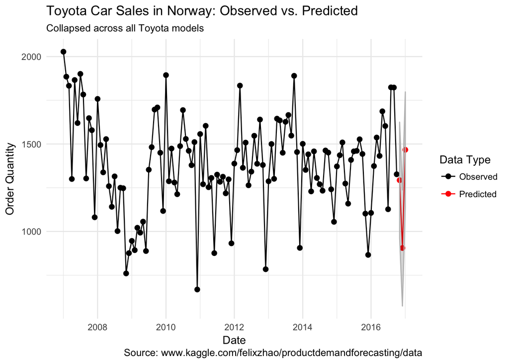

```r
yy <- rbind(y_df, y_df2)

yy %>%
  ggplot(aes(x=Date, y=Demand, color=type)) +
  geom_line() +
  geom_point(size=2) +
  theme_minimal() +
  scale_color_manual(values=c("#000000", "#ff0000")) +
  geom_ribbon(aes(ymin = lower, ymax = upper), alpha=0.2, color="grey") +
  labs(y="Order Quantity",
       x="Date",
       color="Data Type",
       title="Toyota Car Sales in Norway: Observed vs. Predicted",
       subtitle="Collapsed across all Toyota models",
       caption="Source: www.kaggle.com/felixzhao/productdemandforecasting/data")
```

### Testing Error

The difference between the predicted and observed values for the next 3 months can be observed below. For the month of November 2016 the difference is 81.87, meaning the prediction is off by 82. The positive sign suggests that demand was under predicted by this amount. This degree of error is not too substantial given that demand for the month was 1,375.

```r
c(test_toy[1,5] - fc_mod$mean[1],
  test_toy[2,5] - fc_mod$mean[2],
  test_toy[3,5] - fc_mod$mean[3])
```

```
##         1         2         3
##  81.87807 332.65585  59.05576
```

### Final Model

The data frame ‘final_toy’ is created to hold the training and test datasets, with ‘Date’ again being defined as a combination of month and year.

```r
final_toy <- by_make %>%
  mutate(Date=as.Date(paste(Year, Month, "1", sep="-"))) %>%
  select(Date, Year, Month, Make, Quantity) %>%
  filter(Make=="Toyota")
```

The ‘Quantity’ variable is defined as the time series object, ‘y2’, with the frequency again set to 12, reflecting the monthly measurements.

```r
y2 <- final_toy$Quantity %>%
  ts(frequency=12) %>%
  tsclean()
```

```r
lm_mod2 <- tslm(y2 ~ trend + season)

fc_mod2 <- forecast(lm_mod2, h=3)
```

The graph below depicting the forecast is created in the same manner as the previous one. However, the dates for the 3 predicted months must be entered manually.

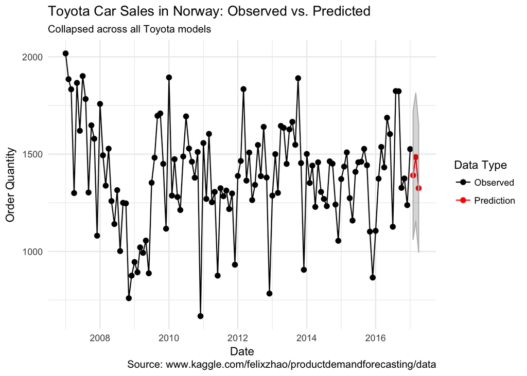

```r
y_df3 <- as.data.frame(as.numeric(y2)) # Create df
colnames(y_df3) <- "Demand" # Rename column.

y_df3$Date <- final_toy$Date # Attach date.
y_df3$upper <- y_df3$lower <- NA # Create empty columns
y_df3$type <- "Observed"

# Prepare Test Data
y_df4 <- as.data.frame(as.numeric(fc_mod2$mean)) # Create df
colnames(y_df4) <- "Demand"

y_df4$Date <- as.Date(c("02/01/2017", "03/01/2017", "04/01/2017"), "%m/%d/%Y")
y_df4$upper <- fc_mod2$upper
y_df4$lower <- fc_mod2$lower
y_df4$type <- "Prediction"

yy2 <- rbind(y_df3, y_df4)

yy2 %>%
  ggplot(aes(x=Date, y=Demand, color=type)) +
  geom_line() +
  geom_point(size=2) +
  theme_minimal() +
  scale_color_manual(values=c("#000000", "#ff0000")) +
  geom_ribbon(aes(ymin = lower, ymax = upper),
              alpha=0.2, color="grey") +
  labs(y="Order Quantity",
       x="Date",
       color="Data Type",
       title="Toyota Car Sales in Norway: Observed vs. Predicted",
       subtitle="Collapsed across all Toyota models",
       caption="Source: www.kaggle.com/felixzhao/productdemandforecasting/data")
```

### Next Steps

At this point in the analysis process, one should begin to experiment with other models, and in doing so repeat the same process of trying to predict the final 3 months of data from a training model. To do this compare the residuals, and if the residuals are larger, then keep the regression model. Otherwise select the new model, and then keep experimenting with other models until you settle on the best fit.

Another popular way of comparing time series models is to use cross validation, which I will demonstrate in ‘Part 2’ of this tutorial.